# Credit Card Fraud Detection (Task 2)

```python
#Importing The Libraries
import pandas as pd
from sklearn.preprocessing import StandardScaler
sc=StandardScaler()
import seaborn as sns
import matplotlib.pyplot as plt
from sklearn.model_selection import train_test_split
from sklearn.linear_model import LogisticRegression
log=LogisticRegression()
from sklearn.tree import DecisionTreeClassifier
dt=DecisionTreeClassifier()
from sklearn.ensemble import RandomForestClassifier
rf=RandomForestClassifier()
rf1=RandomForestClassifier()

from sklearn.metrics import accuracy_score,precision_score,recall_score,f1_score
from sklearn.metrics import classification_report
from imblearn.over_sampling import SMOTE
import joblib
import joblib
import tkinter as tk
from tkinter import messagebox
import pyttsx3
```

```python
#Reading the creditcard.csv file into DataFrame
creditcard_df=pd.read_csv('creditcard.csv')
```

```python
#By Setting it to None means that there is no maximum limit imposed on the number of columns displayed
pd.options.display.max_columns=None
```

```python
#Displaying the First 5 rows of the dataset
creditcard_df.head()
```

|  | Time | V1 | V2 | V3 | V4 | V5 | V6 | V7 | V8 | V9 | V10 | V11 | V12 | V13 | V14 | V15 | V16 | V17 | V18 | V19 | V20 | V21 | V22 | V23 | V24 | V25 | V26 | V27 | V28 | … |
| --- | --- | --- | --- | --- | --- | --- | --- | --- | --- | --- | --- | --- | --- | --- | --- | --- | --- | --- | --- | --- | --- | --- | --- | --- | --- | --- | --- | --- | --- | --- |
| 0 | 0.0 | -1.359807 | -0.072781 | 2.536347 | 1.378155 | -0.338321 | 0.462388 | 0.239599 | 0.098698 | 0.363787 | 0.090794 | -0.551600 | -0.617801 | -0.991390 | -0.311169 | 1.468177 | -0.470401 | 0.207971 | 0.025791 | 0.403993 | 0.251412 | -0.018307 | 0.277838 | -0.110474 | 0.066928 | 0.128539 | -0.189115 | 0.133558 | -0.021053 | … |
| 1 | 0.0 | 1.191857 | 0.266151 | 0.166480 | 0.448154 | 0.060018 | -0.082361 | -0.078803 | 0.085102 | -0.255425 | -0.166974 | 1.612727 | 1.065235 | 0.489095 | -0.143772 | 0.635558 | 0.463917 | -0.114805 | -0.183361 | -0.145783 | -0.069083 | -0.225775 | -0.638672 | 0.101288 | -0.339846 | 0.167170 | 0.125895 | -0.008983 | 0.014724 | … |
| 2 | 1.0 | -1.358354 | -1.340163 | 1.773209 | 0.379780 | -0.503198 | 1.800499 | 0.791461 | 0.247676 | -1.514654 | 0.207643 | 0.624501 | 0.066084 | 0.717293 | -0.165946 | 2.345865 | -2.890083 | 1.109969 | -0.121359 | -2.261857 | 0.524980 | 0.247998 | 0.771679 | 0.909412 | -0.689281 | -0.327642 | -0.139097 | -0.055353 | -0.059752 | … |
| 3 | 1.0 | -0.966272 | -0.185226 | 1.792993 | -0.863291 | -0.010309 | 1.247203 | 0.237609 | 0.377436 | -1.387024 | -0.054952 | -0.226487 | 0.178228 | 0.507757 | -0.287924 | -0.631418 | -1.059647 | -0.684093 | 1.965775 | -1.232622 | -0.208038 | -0.108300 | 0.005274 | -0.190321 | -1.175575 | 0.647376 | -0.221929 | 0.062723 | 0.061458 | … |
| 4 | 2.0 | -1.158233 | 0.877737 | 1.548718 | 0.403034 | -0.407193 | 0.095921 | 0.592941 | -0.270533 | 0.817739 | 0.753074 | -0.822843 | 0.538196 | 1.345852 | -1.119670 | 0.175121 | -0.451449 | -0.237033 | -0.038195 | 0.803487 | 0.408542 | -0.009431 | 0.798278 | -0.137458 | 0.141267 | -0.206010 | 0.502292 | 0.219422 | 0.215153 | … |

```python
#Displaying the Last 5 rows of the dataset
creditcard_df.tail()
```

|  | Time | V1 | V2 | V3 | V4 | V5 | V6 | V7 | V8 | V9 | V10 | V11 | V12 | V13 | V14 | V15 | V16 | V17 | V18 | V19 | V20 | V21 | V22 | V23 | V24 | V25 | V26 | V27 | V28 | … |
| --- | --- | --- | --- | --- | --- | --- | --- | --- | --- | --- | --- | --- | --- | --- | --- | --- | --- | --- | --- | --- | --- | --- | --- | --- | --- | --- | --- | --- | --- | --- |
| 284802 | 172786.0 | -11.881118 | 10.071785 | -9.834783 | -2.066656 | -5.364473 | -2.606837 | -4.918215 | 7.305334 | 1.914428 | 4.356170 | -1.593105 | 2.711941 | -0.689256 | 4.626942 | -0.924459 | 1.107641 | 1.991691 | 0.510632 | -0.682920 | 1.475829 | 0.213454 | 0.111864 | 1.014480 | -0.509348 | 1.436807 | 0.250034 | 0.943651 | 0.823731 | … |
| 284803 | 172787.0 | -0.732789 | -0.055080 | 2.035030 | -0.738589 | 0.868229 | 1.058415 | 0.024330 | 0.294869 | 0.584800 | -0.975926 | -0.150189 | 0.915802 | 1.214756 | -0.675143 | 1.164931 | -0.711757 | -0.025693 | -1.221179 | -1.545556 | 0.059616 | 0.214205 | 0.924384 | 0.012463 | -1.016226 | -0.606624 | -0.395255 | 0.068472 | -0.053527 | … |
| 284804 | 172788.0 | 1.919565 | -0.301254 | -3.249640 | -0.557828 | 2.630515 | 3.031260 | -0.296827 | 0.708417 | 0.432454 | -0.484782 | 0.411614 | 0.063119 | -0.183699 | -0.510602 | 1.329284 | 0.140716 | 0.313502 | 0.395652 | -0.577252 | 0.001396 | 0.232045 | 0.578229 | -0.037501 | 0.640134 | 0.265745 | -0.087371 | 0.004455 | -0.026561 | … |
| 284805 | 172788.0 | -0.240440 | 0.530483 | 0.702510 | 0.689799 | -0.377961 | 0.623708 | -0.686180 | 0.679145 | 0.392087 | -0.399126 | -1.933849 | -0.962886 | -1.042082 | 0.449624 | 1.962563 | -0.608577 | 0.509928 | 1.113981 | 2.897849 | 0.127434 | 0.265245 | 0.800049 | -0.163298 | 0.123205 | -0.569159 | 0.546668 | 0.108821 | 0.104533 | … |
| 284806 | 172792.0 | -0.533413 | -0.189733 | 0.703337 | -0.506271 | -0.012546 | -0.649617 | 1.577006 | -0.414650 | 0.486180 | -0.915427 | -1.040458 | -0.031513 | -0.188093 | -0.084316 | 0.041333 | -0.302620 | -0.660377 | 0.167430 | -0.256117 | 0.382948 | 0.261057 | 0.643078 | 0.376777 | 0.008797 | -0.473649 | -0.818267 | -0.002415 | 0.013649 | … |

```python
#Shape of the dataset
creditcard_df.shape
```

```
(284807, 31)
```

```python
#Displaying the number of rows and columns of the dataset
print("Number of Rows:",creditcard_df.shape[0])
print("Number of Columns:",creditcard_df.shape[1])
```

```
Number of Rows: 284807
Number of Columns: 31
```

```python
#Information about shape of the dataset,datatypes,null values and memory requirements
creditcard_df.info()
```

```
<class 'pandas.core.frame.DataFrame'>
RangeIndex: 284807 entries, 0 to 284806
Data columns (total 31 columns):
 #   Column  Non-Null Count   Dtype
---  ------  --------------   -----
 0   Time    284807 non-null  float64
 1   V1      284807 non-null  float64
 2   V2      284807 non-null  float64
 3   V3      284807 non-null  float64
 4   V4      284807 non-null  float64
 5   V5      284807 non-null  float64
 6   V6      284807 non-null  float64
 7   V7      284807 non-null  float64
 8   V8      284807 non-null  float64
 9   V9      284807 non-null  float64
```

[output cut: 23 more lines]

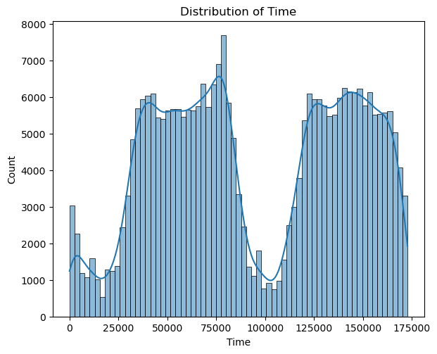

```python
#Visualizing the distribution of Time which provides insights into the frequency of time
plt.figure(figsize=(15,12))
plt.subplot(2,2,2)
sns.histplot(creditcard_df['Time'], kde=True)
plt.title("Distribution of Time")
plt.show()
```

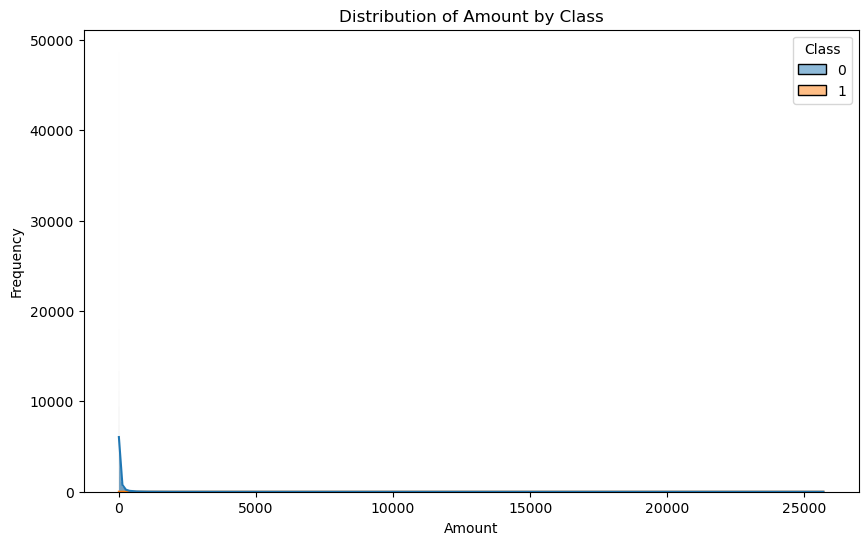

```python
#Visualizing the distribution of Amount by Class
plt.figure(figsize=(10,6))
sns.histplot(creditcard_df,x='Amount',hue='Class',multiple='stack',kde=True)
plt.xlabel('Amount')
plt.ylabel('Frequency')
plt.title('Distribution of Amount by Class')
plt.show()
```

```python
#A DataFrame of the same shape as creditcard_df where each element is either True if the corresponding element in creditcard_df is NaN (missing),and False otherwise.
creditcard_df.isnull()
```

|  | Time | V1 | V2 | V3 | V4 | V5 | V6 | V7 | V8 | V9 | V10 | V11 | V12 | V13 | V14 | V15 | V16 | V17 | V18 | V19 | V20 | V21 | V22 | V23 | V24 | V25 | V26 | V27 | V28 | … |
| --- | --- | --- | --- | --- | --- | --- | --- | --- | --- | --- | --- | --- | --- | --- | --- | --- | --- | --- | --- | --- | --- | --- | --- | --- | --- | --- | --- | --- | --- | --- |
| 0 | False | False | False | False | False | False | False | False | False | False | False | False | False | False | False | False | False | False | False | False | False | False | False | False | False | False | False | False | False | … |
| 1 | False | False | False | False | False | False | False | False | False | False | False | False | False | False | False | False | False | False | False | False | False | False | False | False | False | False | False | False | False | … |
| 2 | False | False | False | False | False | False | False | False | False | False | False | False | False | False | False | False | False | False | False | False | False | False | False | False | False | False | False | False | False | … |
| 3 | False | False | False | False | False | False | False | False | False | False | False | False | False | False | False | False | False | False | False | False | False | False | False | False | False | False | False | False | False | … |
| 4 | False | False | False | False | False | False | False | False | False | False | False | False | False | False | False | False | False | False | False | False | False | False | False | False | False | False | False | False | False | … |
| ... | ... | ... | ... | ... | ... | ... | ... | ... | ... | ... | ... | ... | ... | ... | ... | ... | ... | ... | ... | ... | ... | ... | ... | ... | ... | ... | ... | ... | ... | … |
| 284802 | False | False | False | False | False | False | False | False | False | False | False | False | False | False | False | False | False | False | False | False | False | False | False | False | False | False | False | False | False | … |
| 284803 | False | False | False | False | False | False | False | False | False | False | False | False | False | False | False | False | False | False | False | False | False | False | False | False | False | False | False | False | False | … |
| 284804 | False | False | False | False | False | False | False | False | False | False | False | False | False | False | False | False | False | False | False | False | False | False | False | False | False | False | False | False | False | … |
| 284805 | False | False | False | False | False | False | False | False | False | False | False | False | False | False | False | False | False | False | False | False | False | False | False | False | False | False | False | False | False | … |
| 284806 | False | False | False | False | False | False | False | False | False | False | False | False | False | False | False | False | False | False | False | False | False | False | False | False | False | False | False | False | False | … |

284807 rows × 31 columns

```python
#The sum of missing values for each column in the DataFrame
creditcard_df.isnull().sum()
```

```
Time      0
V1        0
V2        0
V3        0
V4        0
V5        0
V6        0
V7        0
V8        0
V9        0
V10       0
V11       0
V12       0
V13       0
V14       0
V15       0
V16       0
V17       0
V18       0
V19       0
V20       0
V21       0
V22       0
V23       0
V24       0
V25       0
V26       0
V27       0
V28       0
Amount    0
Class     0
dtype: int64
```

```python
#Due to the varying range of amounts across all rows, feature scaling is applied to standardize the 'amount' feature.
creditcard_df.head()
```

|  | Time | V1 | V2 | V3 | V4 | V5 | V6 | V7 | V8 | V9 | V10 | V11 | V12 | V13 | V14 | V15 | V16 | V17 | V18 | V19 | V20 | V21 | V22 | V23 | V24 | V25 | V26 | V27 | V28 | … |
| --- | --- | --- | --- | --- | --- | --- | --- | --- | --- | --- | --- | --- | --- | --- | --- | --- | --- | --- | --- | --- | --- | --- | --- | --- | --- | --- | --- | --- | --- | --- |
| 0 | 0.0 | -1.359807 | -0.072781 | 2.536347 | 1.378155 | -0.338321 | 0.462388 | 0.239599 | 0.098698 | 0.363787 | 0.090794 | -0.551600 | -0.617801 | -0.991390 | -0.311169 | 1.468177 | -0.470401 | 0.207971 | 0.025791 | 0.403993 | 0.251412 | -0.018307 | 0.277838 | -0.110474 | 0.066928 | 0.128539 | -0.189115 | 0.133558 | -0.021053 | … |
| 1 | 0.0 | 1.191857 | 0.266151 | 0.166480 | 0.448154 | 0.060018 | -0.082361 | -0.078803 | 0.085102 | -0.255425 | -0.166974 | 1.612727 | 1.065235 | 0.489095 | -0.143772 | 0.635558 | 0.463917 | -0.114805 | -0.183361 | -0.145783 | -0.069083 | -0.225775 | -0.638672 | 0.101288 | -0.339846 | 0.167170 | 0.125895 | -0.008983 | 0.014724 | … |
| 2 | 1.0 | -1.358354 | -1.340163 | 1.773209 | 0.379780 | -0.503198 | 1.800499 | 0.791461 | 0.247676 | -1.514654 | 0.207643 | 0.624501 | 0.066084 | 0.717293 | -0.165946 | 2.345865 | -2.890083 | 1.109969 | -0.121359 | -2.261857 | 0.524980 | 0.247998 | 0.771679 | 0.909412 | -0.689281 | -0.327642 | -0.139097 | -0.055353 | -0.059752 | … |
| 3 | 1.0 | -0.966272 | -0.185226 | 1.792993 | -0.863291 | -0.010309 | 1.247203 | 0.237609 | 0.377436 | -1.387024 | -0.054952 | -0.226487 | 0.178228 | 0.507757 | -0.287924 | -0.631418 | -1.059647 | -0.684093 | 1.965775 | -1.232622 | -0.208038 | -0.108300 | 0.005274 | -0.190321 | -1.175575 | 0.647376 | -0.221929 | 0.062723 | 0.061458 | … |
| 4 | 2.0 | -1.158233 | 0.877737 | 1.548718 | 0.403034 | -0.407193 | 0.095921 | 0.592941 | -0.270533 | 0.817739 | 0.753074 | -0.822843 | 0.538196 | 1.345852 | -1.119670 | 0.175121 | -0.451449 | -0.237033 | -0.038195 | 0.803487 | 0.408542 | -0.009431 | 0.798278 | -0.137458 | 0.141267 | -0.206010 | 0.502292 | 0.219422 | 0.215153 | … |

```python
#Performing feature scaling on the 'Amount' column of the DataFrame creditcard_df using StandardScaler(sc).
creditcard_df['Amount']=sc.fit_transform(pd.DataFrame(creditcard_df['Amount']))
```

```python
#Removing the 'Time' column from the DataFrame creditcard_df.
creditcard_df=creditcard_df.drop(['Time'],axis=1)
```

```python
#The Time Column is Dropped
creditcard_df.head()
```

|  | V1 | V2 | V3 | V4 | V5 | V6 | V7 | V8 | V9 | V10 | V11 | V12 | V13 | V14 | V15 | V16 | V17 | V18 | V19 | V20 | V21 | V22 | V23 | V24 | V25 | V26 | V27 | V28 | Amount | … |
| --- | --- | --- | --- | --- | --- | --- | --- | --- | --- | --- | --- | --- | --- | --- | --- | --- | --- | --- | --- | --- | --- | --- | --- | --- | --- | --- | --- | --- | --- | --- |
| 0 | -1.359807 | -0.072781 | 2.536347 | 1.378155 | -0.338321 | 0.462388 | 0.239599 | 0.098698 | 0.363787 | 0.090794 | -0.551600 | -0.617801 | -0.991390 | -0.311169 | 1.468177 | -0.470401 | 0.207971 | 0.025791 | 0.403993 | 0.251412 | -0.018307 | 0.277838 | -0.110474 | 0.066928 | 0.128539 | -0.189115 | 0.133558 | -0.021053 | 0.244964 | … |
| 1 | 1.191857 | 0.266151 | 0.166480 | 0.448154 | 0.060018 | -0.082361 | -0.078803 | 0.085102 | -0.255425 | -0.166974 | 1.612727 | 1.065235 | 0.489095 | -0.143772 | 0.635558 | 0.463917 | -0.114805 | -0.183361 | -0.145783 | -0.069083 | -0.225775 | -0.638672 | 0.101288 | -0.339846 | 0.167170 | 0.125895 | -0.008983 | 0.014724 | -0.342475 | … |
| 2 | -1.358354 | -1.340163 | 1.773209 | 0.379780 | -0.503198 | 1.800499 | 0.791461 | 0.247676 | -1.514654 | 0.207643 | 0.624501 | 0.066084 | 0.717293 | -0.165946 | 2.345865 | -2.890083 | 1.109969 | -0.121359 | -2.261857 | 0.524980 | 0.247998 | 0.771679 | 0.909412 | -0.689281 | -0.327642 | -0.139097 | -0.055353 | -0.059752 | 1.160686 | … |
| 3 | -0.966272 | -0.185226 | 1.792993 | -0.863291 | -0.010309 | 1.247203 | 0.237609 | 0.377436 | -1.387024 | -0.054952 | -0.226487 | 0.178228 | 0.507757 | -0.287924 | -0.631418 | -1.059647 | -0.684093 | 1.965775 | -1.232622 | -0.208038 | -0.108300 | 0.005274 | -0.190321 | -1.175575 | 0.647376 | -0.221929 | 0.062723 | 0.061458 | 0.140534 | … |
| 4 | -1.158233 | 0.877737 | 1.548718 | 0.403034 | -0.407193 | 0.095921 | 0.592941 | -0.270533 | 0.817739 | 0.753074 | -0.822843 | 0.538196 | 1.345852 | -1.119670 | 0.175121 | -0.451449 | -0.237033 | -0.038195 | 0.803487 | 0.408542 | -0.009431 | 0.798278 | -0.137458 | 0.141267 | -0.206010 | 0.502292 | 0.219422 | 0.215153 | -0.073403 | … |

```python
#Before Removing the Duplicate Values
creditcard_df.shape
```

```
(284807, 30)
```

```python
#Checking for the Duplicate Values in the Dataframe
creditcard_df.duplicated().any()
```

```
True
```

```python
#Eliminating the duplicate Values in the Dataframe
creditcard_df=creditcard_df.drop_duplicates()
```

```python
#After Removing the Duplicate Values
creditcard_df.shape
```

```
(275663, 30)
```

```python
#The Total number of duplicates removed
284807-275663
```

```
9144
```

### If Not Addressing the imbalance in Dataframe

```python
#Count of the number of occurrences for each unique value in the 'Class' column used to understand the distribution of classes in a binary classification problem
creditcard_df['Class'].value_counts()
```

```
Class
0    275190
1       473
Name: count, dtype: int64
```

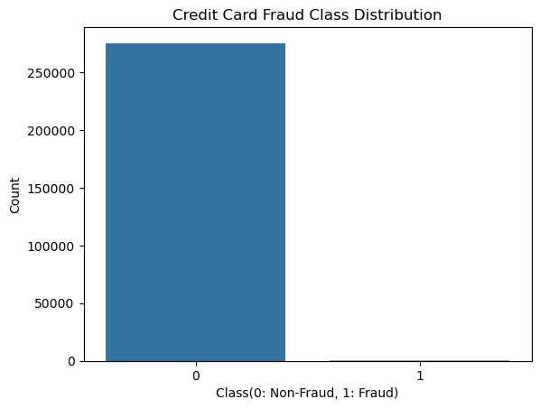

```python
#Visualizing the Class distribution between Fraudulent and Normal Transactions.
sns.countplot(x='Class',data=creditcard_df)
plt.xlabel('Class(0: Non-Fraud, 1: Fraud)')
plt.ylabel('Count')
plt.title('Credit Card Fraud Class Distribution')
plt.show()
```

The dataset exhibits a significant class imbalance, where one class is represented by a considerably higher number of observations compared to the other class, which is characterized by a substantially lower number of observations. This imbalance can potentially impact the performance of machine learning models, leading to a bias towards the majority class and suboptimal predictions for the minority class.

```python
#Storing Feature Matrix in 'X' and Target Variable in 'Y'
X=creditcard_df.drop('Class',axis=1) #X contains independent variables
Y=creditcard_df['Class'] #Y contains dependent variables
```

```python
#Splitting the dataset into Training set and Test set
X_train,X_test,Y_train,Y_test=train_test_split(X,Y,test_size=0.20,random_state=42)
```

### Training the Model using Logistic Regression to show the imbalance in dataset

```python
#Training the Model using Logistic Regression
log.fit(X_train,Y_train)
```

```
LogisticRegression()
```

```python
#Predicting the Model using Logistic Regression
Y_predict=log.predict(X_test)
```

```python
#Accuracy Score:
accuracy_score(Y_test,Y_predict)
```

```
0.9992200678359603
```

```python
#Precision Score
precision_score(Y_test,Y_predict)
```

```
0.8870967741935484
```

```python
#Recall Score:
recall_score(Y_test,Y_predict)
```

```
0.6043956043956044
```

```python
#F1 Score:
f1_score(Y_test,Y_predict)
```

```
0.718954248366013
```

Due to the imbalanced nature of the dataset, the precision, recall, and F1 scores exhibit lower values in comparison to accuracy.In imbalanced datasets, it's common for the model to achieve high accuracy by simply predicting the majority class, but this may not be meaningful in practice. To address this, we can consider using techniques such as resampling, changing the classification threshold, or using specialized algorithms designed to handle imbalanced datasets.

### Handling Imbalanced Dataset

Addressing this class imbalance is essential to ensure the model's accuracy and effectiveness in detecting both fraudulent and non-fraudulent transactions. Techniques like undersampling and oversampling can be employed to balance the class distribution and enhance the model's performance.

### Undersampling

Undersampling is a technique used in imbalanced datasets to reduce the number of samples in the majority class to match the size of the minority class, thereby creating a balanced dataset for model training.

```python
#Storing Normal transactions in 'normal' variable and Fraud transactions in 'fraud' variable
normal=creditcard_df[creditcard_df['Class']==0]
fraud=creditcard_df[creditcard_df['Class']==1]
```

```python
#The number of Normal transactions
normal.shape
```

```
(275190, 30)
```

```python
#The number of Fraud transactions
fraud.shape
```

```
(473, 30)
```

```python
#A sample of 473 randomly selected instances is taken from the 'normal' DataFrame, and the resulting DataFrame is assigned to the variable 'normal_sample'.
normal_sample=normal.sample(n=473)
normal_sample.shape
```

```
(473, 30)
```

```python
#A new DataFrame 'newcreditcard_df' is created by concatenating a sample of normal transactions with the entire fraud transactions DataFrame, and the resulting distribution of the 'Class' variable is displayed using the value counts.
newcreditcard_df=pd.concat([normal_sample,fraud],ignore_index=True)
newcreditcard_df['Class'].value_counts()
```

```
Class
0    473
1    473
Name: count, dtype: int64
```

```python
#The new dataframe after performing Undersampling
newcreditcard_df.head()
```

|  | V1 | V2 | V3 | V4 | V5 | V6 | V7 | V8 | V9 | V10 | V11 | V12 | V13 | V14 | V15 | V16 | V17 | V18 | V19 | V20 | V21 | V22 | V23 | V24 | V25 | V26 | V27 | V28 | Amount | … |
| --- | --- | --- | --- | --- | --- | --- | --- | --- | --- | --- | --- | --- | --- | --- | --- | --- | --- | --- | --- | --- | --- | --- | --- | --- | --- | --- | --- | --- | --- | --- |
| 0 | 1.235287 | 0.466880 | -0.136739 | 1.055571 | 0.237605 | -0.720566 | 0.484040 | -0.225830 | -0.306209 | -0.002901 | -0.113415 | 0.384879 | 0.133192 | 0.560867 | 0.916589 | -0.517040 | -0.043066 | -0.838788 | -0.612346 | -0.178341 | 0.031972 | 0.194293 | -0.116967 | 0.099327 | 0.785370 | -0.267196 | 0.009713 | 0.007764 | -0.349671 | … |
| 1 | 1.280454 | 0.266543 | 0.132944 | 0.619602 | -0.292421 | -0.892918 | 0.006593 | -0.119938 | 0.219491 | -0.250737 | -0.570582 | -0.454020 | -0.783476 | -0.095609 | 1.237925 | 0.633718 | -0.074696 | -0.050271 | -0.055711 | -0.137419 | -0.323458 | -0.984066 | 0.097606 | -0.044281 | 0.227725 | 0.120285 | -0.030591 | 0.024907 | -0.345313 | … |
| 2 | -4.634871 | -1.736489 | -1.404065 | -0.340790 | -1.123951 | 2.399643 | 0.552142 | 1.116064 | 0.323240 | -0.800774 | 0.789472 | 0.929476 | 0.213995 | 0.715782 | 1.421361 | 0.251054 | 0.166029 | -0.342587 | -0.602107 | -1.227204 | 0.065579 | 0.875555 | -1.449331 | -0.597017 | -0.481529 | 0.162795 | -0.021474 | -0.942629 | 1.246245 | … |
| 3 | -1.338059 | -0.866751 | 2.306920 | -2.455605 | -0.076509 | -0.368510 | -0.491387 | 0.322461 | 1.264275 | -1.815492 | 0.602330 | 1.122517 | 0.507892 | -0.350069 | 0.676760 | 0.205917 | -0.873057 | 1.362471 | 0.822713 | 0.383739 | 0.384173 | 0.914646 | -0.213388 | -0.284304 | 0.543451 | -0.046701 | 0.045115 | 0.079915 | -0.056451 | … |
| 4 | -4.078124 | -8.933056 | -1.555444 | 3.733766 | -3.360488 | 2.425969 | 2.492109 | -0.226935 | 1.332355 | -1.703092 | -1.829824 | 1.095623 | 1.141761 | -0.652164 | -1.029442 | -0.249766 | 0.326320 | 0.062026 | -0.728461 | 5.338591 | 1.538807 | -1.081628 | -2.544736 | -0.567119 | -0.364052 | -0.431467 | -0.377778 | 0.495658 | 10.412257 | … |

### Evaluating After Performing UnderSampling

```python
#Storing Feature Matrix in 'X' and Target Variable in 'Y'
X=newcreditcard_df.drop('Class',axis=1) #X contains independent variables
Y=newcreditcard_df['Class'] #Y contains dependent variables
```

```python
#Splitting the dataset into Training set and Test set
X_train,X_test,Y_train,Y_test=train_test_split(X,Y,test_size=0.20,random_state=42)
```

##### Training the Model using Logistic Regression after performing Undersampling

```python
#Training the Model using Logistic Regression
log.fit(X_train,Y_train)
```

```
LogisticRegression()
```

```python
#Predicting the Model using Logistic Regression
Y_predict1=log.predict(X_test)
```

```python
#Accuracy Score:
accuracy_score(Y_test,Y_predict1)
```

```
0.9421052631578948
```

```python
#Precision Score
precision_score(Y_test,Y_predict1)
```

```
0.9789473684210527
```

```python
#Recall Score:
recall_score(Y_test,Y_predict1)
```

```
0.9117647058823529
```

```python
#F1 Score:
f1_score(Y_test,Y_predict1)
```

```
0.9441624365482234
```

For imbalanced datasets, it is crucial to assess performance using metrics beyond accuracy, such as precision, recall, and F1-score, to obtain a more comprehensive evaluation of model effectiveness in capturing true positives, minimizing false negatives, and maintaining a balance between precision and recall.

##### Training the Model using Decision Tree Classifier after performing Undersampling

```python
#Training the Model Using Decision Tree Classifier
dt.fit(X_train,Y_train)
```

```
DecisionTreeClassifier()
```

```python
#Predicting the Model Using Decision Tree Classifier
Y_predict2=dt.predict(X_test)
```

```python
#Accuracy Score:
accuracy_score(Y_test,Y_predict2)
```

```
0.9368421052631579
```

```python
#Precision Score:
precision_score(Y_test,Y_predict2)
```

```
0.96875
```

```python
#Recall Score:
recall_score(Y_test,Y_predict2)
```

```
0.9117647058823529
```

```python
#F1 Score:
f1_score(Y_test,Y_predict2)
```

```
0.9393939393939394
```

##### Training the Model using Random Forest Classifier after performing Undersampling

```python
#Training the model using Random Forest Classifier
rf.fit(X_train,Y_train)
```

```
RandomForestClassifier()
```

```python
#Predicting the model using Random Forest Classifier
Y_predict3=rf.predict(X_test)
```

```python
#Accuracy Score:
accuracy_score(Y_test,Y_predict3)
```

```
0.9421052631578948
```

```python
#Precision Score:
precision_score(Y_test,Y_predict3)
```

```
0.989247311827957
```

```python
#Recall Score:
recall_score(Y_test,Y_predict3)
```

```
0.9019607843137255
```

```python
#F1 Score:
f1_score(Y_test,Y_predict3)
```

```
0.9435897435897437
```

##### Visualizing the Evaluation of the Models

```python
final_accuracydata=pd.DataFrame({'Models':['LR','DT','RF'],"Accuracy":
                                                          [accuracy_score(Y_test,Y_predict1)*100,
                                                          accuracy_score(Y_test,Y_predict2)*100,
                                                          accuracy_score(Y_test,Y_predict3)*100]})
final_accuracydata
```

|  | Models | Accuracy |
| --- | --- | --- |
| 0 | LR | 94.210526 |
| 1 | DT | 93.684211 |
| 2 | RF | 94.210526 |

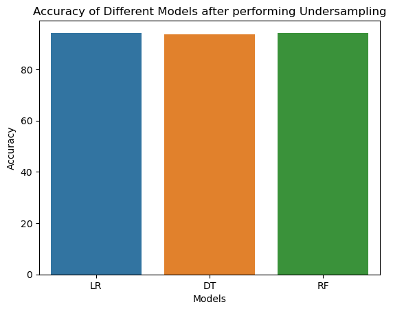

```python
sns.barplot(x='Models',y='Accuracy',data=final_accuracydata)
plt.xlabel('Models')
plt.ylabel('Accuracy')
plt.title('Accuracy of Different Models after performing Undersampling')
plt.show()
```

While undersampling reduces the majority class samples to balance the dataset, it may lead to information loss and reduced model performance due to the removal of the important instances. By combining oversampling with undersampling, we can achieve a more balanced dataset with a sufficient number of instances for both classes, which can improve the model's ability to make accurate predictions for the minority class.

### OverSampling

Oversampling is a technique used in machine learning to address class imbalance by artificially increasing the number of instances in the minority class. This involves duplicating or creating synthetic samples of the minority class to ensure a more equitable representation of both classes in the training dataset. The goal is to improve the model's ability to learn patterns from the minority class, resulting in better generalization and performance on unseen data.

SMOTE is one of the most commonly used oversampling technique to solve imbalanced datasets. It selects a random minority class instance and finds its k-nearest neighbors and then the synthetic samples are generated along the line segments connecting the original instance and its k-nearest neighbors.

```python
#Store the feature matrix in vector 'X' and reseponse in vector 'Y'
X=creditcard_df.drop('Class',axis=1)
Y=creditcard_df['Class']
```

```python
#The shape of X after dropping ‘Class’
X.shape
```

```
(275663, 29)
```

```python
#The shape of Y i.e ‘Class’
Y.shape
```

```
(275663,)
```

```python
#Performing oversampling on the features X and Y
X_result,Y_result=SMOTE().fit_resample(X,Y)
Y_result.value_counts()
```

```
Class
0    275190
1    275190
Name: count, dtype: int64
```

By applying the Synthetic Minority Over-sampling Technique (SMOTE) to features X and Y, new datasets X_result and Y_result are generated. The value counts of the 'Class' variable in Y_result demonstrate that, post-oversampling, both classes (0 and 1) are now equally represented with 275,190 instances each, leading to a balanced dataset.

### Evaluating after performing Oversampling

```python
#Splitting the dataset into the train and test sets
X_train,X_test,Y_train,Y_test=train_test_split(X_result,Y_result,test_size=0.2,random_state=42)
```

##### Training the Model using Logistic Regression after performing Oversampling

```python
#Training the Model using Logistic Regression
log.fit(X_train,Y_train)
```

```
LogisticRegression()
```

```python
#Predicting the Model using Logistic Regression
Y_predict1=log.predict(X_test)
```

```python
#Accuracy Score:
accuracy_score(Y_test,Y_predict1)
```

```
0.9432392165412987
```

```python
#Precision Score
precision_score(Y_test,Y_predict1)
```

```
0.9727161666892901
```

```python
#Recall Score:
recall_score(Y_test,Y_predict1)
```

```
0.9119866189116957
```

```python
#F1 Score:
f1_score(Y_test,Y_predict1)
```

```
0.9413729685095521
```

##### Training the Model using Decision Tree Classifier after performing Oversampling

```python
#Training the Model Using Decision Tree Classifier
dt.fit(X_train,Y_train)
```

```
DecisionTreeClassifier()
```

```python
#Predicting the Model Using Decision Tree Classifier
Y_predict2=dt.predict(X_test)
```

```python
#Accuracy Score:
accuracy_score(Y_test,Y_predict2)
```

```
0.9983375122642538
```

```python
#Precision Score:
precision_score(Y_test,Y_predict2)
```

```
0.997694011693358
```

```python
#Recall Score:
recall_score(Y_test,Y_predict2)
```

```
0.9989818737159791
```

```python
#F1 Score:
f1_score(Y_test,Y_predict2)
```

```
0.9983375273672066
```

##### Training the Model using Random Forest Classifier after performing Oversampling

```python
#Training the model using Random Forest Classifier
rf.fit(X_train,Y_train)
```

```
RandomForestClassifier()
```

```python
#Predicting the model using Random Forest Classifier
Y_predict3=rf.predict(X_test)
```

```python
#Accuracy Score:
accuracy_score(Y_test,Y_predict3)
```

```
0.9999000690432065
```

```python
#Precision Score:
precision_score(Y_test,Y_predict3)
```

```
0.9998000508961356
```

```python
#Recall Score:
recall_score(Y_test,Y_predict3)
```

```
1.0
```

```python
#F1 Score:
f1_score(Y_test,Y_predict3)
```

```
0.9999000154521575
```

##### Visualizing the Evaluation of the Models

```python
final_accuracydata=pd.DataFrame({'Models':['LR','DT','RF'],"Accuracy":
                                                          [accuracy_score(Y_test,Y_predict1)*100,
                                                          accuracy_score(Y_test,Y_predict2)*100,
                                                          accuracy_score(Y_test,Y_predict3)*100]})
final_accuracydata
```

|  | Models | Accuracy |
| --- | --- | --- |
| 0 | LR | 94.323922 |
| 1 | DT | 99.833751 |
| 2 | RF | 99.990007 |

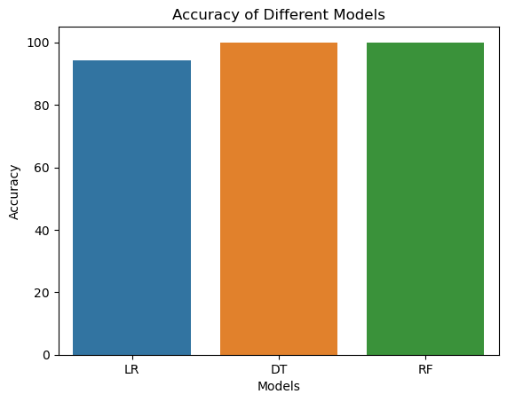

```python
sns.barplot(x='Models',y='Accuracy',data=final_accuracydata)
plt.xlabel('Models')
plt.ylabel('Accuracy')
plt.title('Accuracy of Different Models')
plt.show()
```

### Save The Model

```python
#Saving the Model Random Forest Classifier
rf1.fit(X_result,Y_result)
```

```
RandomForestClassifier()
```

```python
#The RandomForestClassifier model is saved using the Joblib library and stored with the filename "Credit_Card_Model".
joblib.dump(rf1,"Credit_Card_Model")
```

```
['Credit_Card_Model']
```

```python
#Loading the Pre-trained Model Random Forest Classifier
model=joblib.load('Credit_Card_Model')
```

### Predicting the Model

```python
#A prediction is made using the model and the input transactions given in the Dataset
predict=model.predict([[-1.359807,-0.072781,2.536347,1.378155,-0.338321,0.462388,0.239599,0.098698,0.363787,0.090794,-0.551600,-0.617801,-0.991390,-0.311169,1.468177,-0.470401,0.207971,0.025791,0.403993,0.251412,-0.018307,0.277838,-0.110474,0.066928,0.128539,-0.189115,0.133558,-0.021053,149.62]])
```

```python
#Decision-making statement based on the model's prediction.
if predict==0:
       print("Normal Transaction")
else:
        print("Fraudulent Transaction")
```

```
Normal Transaction
```

# GUI APPLICATION

```python
def show_entry_fields():
    # Collecting the input values
    values = [float(entry.get()) for entry in entries]
    # Loading the model
    model = joblib.load('Credit_Card_Model')
    # Making a prediction
    y_predict = model.predict([values])
    # Interpreting the result
    if y_predict == 0:
        result = "Normal Transaction"
    else:
        result = "Fraud Transaction"
    # Displaying the result in a message box
    messagebox.showinfo("Credit Card Fraud Detection System", f"Final Prediction: {result}")
    # Using TTS to speak the result
    engine = pyttsx3.init()
    engine.say(f"The transaction is predicted to be a {result}")
    engine.runAndWait()
# Setting up the main application window
master = tk.Tk()
master.title("Credit Card Fraud Detection System")
# Header label
tk.Label(master, text="Credit Card Fraud Detection System", bg="black", fg="white", width=50).grid(row=0, column=0, columnspan=2)
# Creating entry fields for the features
entries = []
for i in range(1, 30):
    tk.Label(master, text=f"Enter Value of V{i}").grid(row=i, column=0)
    entry = tk.Entry(master)
    entry.grid(row=i, column=1)
    entries.append(entry)
# Centering the predict button
button_frame = tk.Frame(master)
button_frame.grid(row=30, column=0, columnspan=2, pady=10)
predict_button = tk.Button(button_frame, text='PREDICT', command=show_entry_fields, width=10)
predict_button.pack(pady=5, padx=10, ipadx=10, ipady=5)
# Centering the entire window on the screen
window_width = master.winfo_reqwidth()
window_height = master.winfo_reqheight()
position_right = int(master.winfo_screenwidth() / 2 - window_width / 2)
position_down = int(master.winfo_screenheight() / 2 - window_height / 2)
master.geometry("+{}+{}".format(position_right, position_down))
# Running the application
master.mainloop()
```